# Bios 8060E Project

Amanda Blubaugh

last updated: 11/2/2019

# Project Overview

### Transcriptomic profile differences in atopic dermatitis (AD) canid house dust mite (HDM) models when considering using multifactorial differential expression for sensitization of model dogs

Perform differential expression (DE) of previous data from an AD canine model paper in both a multifactoral DE that mimics the original paper (using R open source versus proprietary software of the paper) and in a classic one factor DE without considering an the additional factor of previous canine sensitization to the HDM model. I would like to see how immunological genes that are significantly up or down-regulated change between the two DE evaluations.

The original paper provides a multifactorial differential expression of genes in HDM samples versus 0h control healthy, as well as versus 24h saline, allowing for sensitization of the HDM or not as a factor.

Traditional atopic dermatitis (exzema) canine models for development of human and canine drugs to treat the disease require that all dogs be sensitized to HDM prior to recieving HDM stimulus for modelled skin to AD. canine AD models are essential for drug development in treating AD for humans and canines.

## Goals

Since this paper contains 6 subjects with no previous sensitization, and 6 subjects with sensitization, the goal of this project will be to:

1. Replicate the multifactoral DE of data for all 12 dogs (sensitized or not being the additional factor) at 24h HDM versus 0h untreated no exposure.
2. Do additional individual DE of 6 vs. 6 dogs with no multifactoral consideration for sensitization, since the larger group is divided into two smaller groups that dilineate this factor.

## Hypotheses

It is hypothesized that:

1. Replication of the orginal results will be possible for confirmation of proper manipulation of the data in this study on a multifactoral level and reproducibility to validate the study results.
2. Division of the sample group into smaller, even groups of dogs that have been sensitized or not will provide a DE view that shows differences in DE based on previous sensitization or not, validating whether or not sensitization is required in a HDM canine atopic model.

## Limitations and Justifications

The sample size is quite low for this study, but this is some of the only sample data available for canine AD models to compare sensitized or non- sensitized dogs. We are also not utilizing saline controls of this study, which are still controversial in whether saline itself produces an inflammatory response to the skin.

There is no previous study evaluating the efficacy of first sensitizing dogs to HDM prior to inducing AD models with HDM paste.

## Project Data Source

Samples from a previously published paper by [Schamber et al. (2014)](https://www.ncbi.nlm.nih.gov/pmc/articles/PMC4199687/) will be used for this project and is in project resources.

# Materials and Methods

## Downloading Data from GEOquery (NCBI GEO database)

Prior to working in R studio, I installed [Bioconductor](https://www.bioconductor.org/install/) resources on my local computer through the console, as well as [GEOquery](https://bioconductor.org/packages/release/bioc/html/GEOquery.html) and [limma](https://bioconductor.org/packages/release/bioc/html/limma.html)  
In the console:

```
if (!requireNamespace("BiocManager", quietly = TRUE))
    install.packages("BiocManager")
BiocManager::install()


BiocManager::install(c("Biobase","GEOquery","limma"))
```

## Load libraries for use

```r
library(limma)
library(Biobase)
library(GEOquery)
library(tidyverse)
```

```r
library(ggplot2)
library(RColorBrewer)
```

## Cache data from GEO datasets

```r
#You can search in the NCBI GEOquery database with the GSE number: GSE58442
#The getGEO function in GEOquery library uses this identifier to gather our data
gset <- getGEO("GSE58442", GSEMatrix =TRUE, AnnotGPL=FALSE)
```

```
## Found 1 file(s)
```

```
## GSE58442_series_matrix.txt.gz
```

```
## File stored at:
```

```
## C:\Users\alblu\AppData\Local\Temp\Rtmpu8Suhj/GPL18789.soft
```

```r
if (length(gset) > 1) idx <- grep("GPL18789", attr(gset, "names")) else idx <- 1
gset <- gset[[idx]]
```

### Inspect Uncleaned Data

```r
head(gset)
```

```
## ExpressionSet (storageMode: lockedEnvironment)
## assayData: 1 features, 60 samples
##   element names: exprs
## protocolData: none
## phenoData
##   sampleNames: GSM1411137 GSM1411138 ... GSM1411196 (60 total)
##   varLabels: title geo_accession ... treatment:ch1 (42 total)
##   varMetadata: labelDescription
## featureData
##   featureNames: 1
##   fvarLabels: ID COL ... SEQUENCE (18 total)
##   fvarMetadata: Column Description labelDescription
## experimentData: use 'experimentData(object)'
##   pubMedIds: 25098772
## Annotation: GPL18789
```

```r
head(pData(gset))
```

```
##                   title geo_accession                status
## GSM1411137    A_2838_0h    GSM1411137 Public on Sep 23 2014
## GSM1411138  A_2838_6h_A    GSM1411138 Public on Sep 23 2014
## GSM1411139  A_2838_6h_S    GSM1411139 Public on Sep 23 2014
## GSM1411140 A_2838_24h_A    GSM1411140 Public on Sep 23 2014
## GSM1411141 A_2838_24h_S    GSM1411141 Public on Sep 23 2014
## GSM1411142    A_2839_0h    GSM1411142 Public on Sep 23 2014
##            submission_date last_update_date type channel_count
## GSM1411137     Jun 12 2014      Sep 23 2014  RNA             1
## GSM1411138     Jun 12 2014      Sep 23 2014  RNA             1
## GSM1411139     Jun 12 2014      Sep 23 2014  RNA             1
## GSM1411140     Jun 12 2014      Sep 23 2014  RNA             1
## GSM1411141     Jun 12 2014      Sep 23 2014  RNA             1
## GSM1411142     Jun 12 2014      Sep 23 2014  RNA             1
##                      source_name_ch1           organism_ch1
## GSM1411137         skin_untreated_0h Canis lupus familiaris
## GSM1411138  skin_treated_allergen_6h Canis lupus familiaris
## GSM1411139    skin_treated_saline_6h Canis lupus familiaris
## GSM1411140 skin_treated_allergen_24h Canis lupus familiaris
## GSM1411141   skin_treated_saline_24h Canis lupus familiaris
## GSM1411142         skin_untreated_0h Canis lupus familiaris
##               characteristics_ch1 characteristics_ch1.1
## GSM1411137 group: sensitized dogs        animal #: 2838
## GSM1411138 group: sensitized dogs        animal #: 2838
## GSM1411139 group: sensitized dogs        animal #: 2838
## GSM1411140 group: sensitized dogs        animal #: 2838
## GSM1411141 group: sensitized dogs        animal #: 2838
## GSM1411142 group: sensitized dogs        animal #: 2839
##            characteristics_ch1.2 characteristics_ch1.3
## GSM1411137              time: 0h       treatment: none
## GSM1411138              time: 6h   treatment: allergen
## GSM1411139              time: 6h     treatment: saline
## GSM1411140             time: 24h   treatment: allergen
## GSM1411141             time: 24h     treatment: saline
## GSM1411142              time: 0h       treatment: none
##            characteristics_ch1.4
## GSM1411137          tissue: skin
## GSM1411138          tissue: skin
## GSM1411139          tissue: skin
## GSM1411140          tissue: skin
```

[output cut: 106 more lines]

```
## GSM1411142     ftp://ftp.ncbi.nlm.nih.gov/geo/samples/GSM1411nnn/GSM1411142/suppl/GSM1411142_A_2839_0h_Slide7-2_1_3-51.txt.gz
##            data_row_count animal #:ch1       group:ch1 time:ch1 tissue:ch1
## GSM1411137          62976         2838 sensitized dogs       0h       skin
## GSM1411138          62976         2838 sensitized dogs       6h       skin
## GSM1411139          62976         2838 sensitized dogs       6h       skin
## GSM1411140          62976         2838 sensitized dogs      24h       skin
## GSM1411141          62976         2838 sensitized dogs      24h       skin
## GSM1411142          62976         2839 sensitized dogs       0h       skin
##            treatment:ch1
## GSM1411137          none
## GSM1411138      allergen
## GSM1411139        saline
## GSM1411140      allergen
## GSM1411141        saline
## GSM1411142          none
```

## Preliminary Analysis with GEO2R

```r
# make proper column names to match toptable
fvarLabels(gset) <- make.names(fvarLabels(gset))
fvarLabels(gset)
```

```
##  [1] "ID"                   "COL"                  "ROW"
##  [4] "NAME"                 "SPOT_ID"              "CONTROL_TYPE"
##  [7] "REFSEQ"               "GB_ACC"               "EntrezGene_ID"
## [10] "GENE_SYMBOL"          "GENE_NAME"            "UNIGENE_ID"
## [13] "ENSEMBL_ID"           "ACCESSION_STRING"     "CHROMOSOMAL_LOCATION"
## [16] "DESCRIPTION"          "GO_ID"                "SEQUENCE"
```

```r
# group names for all samples
gsms <- "013240132401324013240132401324013240132401324013240132401324"
sml <- c()
for (i in 1:nchar(gsms)) { sml[i] <- substr(gsms,i,i) }

# log2 transform
ex <- exprs(gset)
qx <- as.numeric(quantile(ex, c(0., 0.25, 0.5, 0.75, 0.99, 1.0), na.rm=T))
LogC <- (qx[5] > 100) ||
  (qx[6]-qx[1] > 50 && qx[2] > 0) ||
  (qx[2] > 0 && qx[2] < 1 && qx[4] > 1 && qx[4] < 2)
if (LogC) { ex[which(ex <= 0)] <- NaN
exprs(gset) <- log2(ex) }

# set up the data and proceed with analysis
sml <- paste("G", sml, sep="")    # set group names
fl <- as.factor(sml)
fl
```

```
##  [1] G0 G1 G3 G2 G4 G0 G1 G3 G2 G4 G0 G1 G3 G2 G4 G0 G1 G3 G2 G4 G0 G1 G3
## [24] G2 G4 G0 G1 G3 G2 G4 G0 G1 G3 G2 G4 G0 G1 G3 G2 G4 G0 G1 G3 G2 G4 G0
## [47] G1 G3 G2 G4 G0 G1 G3 G2 G4 G0 G1 G3 G2 G4
## Levels: G0 G1 G2 G3 G4
```

```r
gset$description <- fl

# Create and view design matrix
design <- model.matrix(~ description + 0, gset)

colnames(design) <- levels(fl)
head(design)
```

```
##            G0 G1 G2 G3 G4
## GSM1411137  1  0  0  0  0
## GSM1411138  0  1  0  0  0
## GSM1411139  0  0  0  1  0
## GSM1411140  0  0  1  0  0
## GSM1411141  0  0  0  0  1
## GSM1411142  1  0  0  0  0
```

```r
# lm function fit with single variable
fit <- lmFit(gset, design)
fit2 <- eBayes(fit)
topTable(fit2)
```

```
##          ID COL ROW                  NAME               SPOT_ID
## 58100 58100  15 242 CUST_5667_PI425858678 CUST_5667_PI425858678
## 39934 39934  71 165          (+)E1A_r60_1          (+)E1A_r60_1
## 40727 40727  68 220          (+)E1A_r60_1          (+)E1A_r60_1
## 17136 17136 140 170          (+)E1A_r60_1          (+)E1A_r60_1
## 35818 35818  83 198          (+)E1A_r60_1          (+)E1A_r60_1
## 39232 39232  73 257          (+)E1A_r60_1          (+)E1A_r60_1
## 9251   9251 164 196          (+)E1A_r60_1          (+)E1A_r60_1
## 36284 36284  82 249          (+)E1A_r60_1          (+)E1A_r60_1
## 60894 60894   7 229          (+)E1A_r60_1          (+)E1A_r60_1
## 52027 52027  34 251          (+)E1A_r60_1          (+)E1A_r60_1
##       CONTROL_TYPE REFSEQ GB_ACC EntrezGene_ID GENE_SYMBOL GENE_NAME
## 58100        FALSE
## 39934          pos
## 40727          pos
## 17136          pos
## 35818          pos
## 39232          pos
## 9251           pos
## 36284          pos
## 60894          pos
## 52027          pos
##       UNIGENE_ID         ENSEMBL_ID       ACCESSION_STRING
## 58100            ENSCAFT00000042294 ens|ENSCAFT00000042294
## 39934
## 40727
## 17136
## 35818
## 39232
## 9251
## 36284
## 60894
## 52027
##       CHROMOSOMAL_LOCATION DESCRIPTION GO_ID
## 58100             unmapped
## 39934
## 40727
## 17136
## 35818
## 39232
```

[output cut: 22 more lines]

```
## 9251  18.17708 18.12538 18.52433 18.09564 18.46371 18.27723 260452.1
## 36284 18.23556 18.16524 18.54313 18.12610 18.48721 18.31145 260272.3
## 60894 18.21562 18.19253 18.53691 18.16102 18.50982 18.32318 260157.3
## 52027 18.26375 18.20822 18.58356 18.17900 18.52945 18.35279 259850.4
##             P.Value     adj.P.Val
## 58100 1.317978e-128 8.300097e-124
## 39934 2.447089e-126 4.565357e-122
## 40727 3.648967e-126 4.565357e-122
## 17136 4.387554e-126 4.565357e-122
## 35818 5.268483e-126 4.565357e-122
## 39232 6.774972e-126 4.565357e-122
## 9251  8.690322e-126 4.565357e-122
## 36284 8.867580e-126 4.565357e-122
## 60894 8.982969e-126 4.565357e-122
## 52027 9.298534e-126 4.565357e-122
```

In this preliminary analysis, we can see which probes had the lowest/best scoring False Discovery Rate (FDR)/ adjusted p-value for change in probe fluoresence (number of bound, tagged fluorescent transcripts to the probe on the microarray) with a basic linear model, adjusted with a Bayesian fit. I don’t have probes that have a gene symbol attached to them separated from those without a gene symbol. I also haven’t viewed other aspects of the data yet (principal component analysis (PCA) for example).

## Aquire additional phenotypic data for local use of samples in this study

Going to [GEO2R](https://www.ncbi.nlm.nih.gov/geo/geo2r/), we can obtain the phenotypic data attached to each sample and label them by number for the design above. This is a way to manipulate the data and get preliminary results without having the raw data directly on the local computer being used.

Phenotypic data for each raw .txt file can be highlighted and read into a .txt file for manipulation with the raw data (i.e. to clean it up in a way we can acheive ultimate our goals in the study)

```r
#Here, we locate where we saved the .txt file we got for reading metadata into a table, notating that the file has tabular separations ("\t" for sep), that there is a header for each column (our variables; header=TRUE), and that we have row names which are the same .txt GSM# .txt files that we have read in previously.

META <- read.AnnotatedDataFrame("./data/processed_data/Schamber_phenotypes.txt", sep="\t", header=TRUE, row.names=1)
head(pData(META))
```

```
##                                                    Type     Color Label
## GSM1411137_A_2838_0h_Slide6-3_2_4-49.txt        noTx_0h darkgreen  2838
## GSM1411138_A_2838_6h_A_Slide6-3_1_3-44.txt       HDM_6h      gold  2838
## GSM1411139_A_2838_6h_S_Slide6-3_1_2-43.txt    saline_6h   orchid2  2838
## GSM1411140_A_2838_24h_A_Slide3-10_1_2-18.txt    HDM_24h firebrick  2838
## GSM1411141_A_2838_24h_S_Slide1-8_2_4-8.txt   saline_24h  darkblue  2838
## GSM1411142_A_2839_0h_Slide7-2_1_3-51.txt        noTx_0h darkgreen  2839
##                                              Sensitized       ColorSens
## GSM1411137_A_2838_0h_Slide6-3_2_4-49.txt              y darkolivegreen1
## GSM1411138_A_2838_6h_A_Slide6-3_1_3-44.txt            y lightgoldenrod2
## GSM1411139_A_2838_6h_S_Slide6-3_1_2-43.txt            y         orchid2
## GSM1411140_A_2838_24h_A_Slide3-10_1_2-18.txt          y          coral1
## GSM1411141_A_2838_24h_S_Slide1-8_2_4-8.txt            y      royalblue1
## GSM1411142_A_2839_0h_Slide7-2_1_3-51.txt              y darkolivegreen1
```

In this metadata information table I have created, I have manually added color identifications in that were not part of the phenotyptic table copied to a .txt file from GEO2R. This is so when I run PCA, we can see which groups may naturally diverge.

## Principal Component Analysis

In PCA, the heirarchical clustering algorithm does not take phenotypic groups into account. Using our additional metadata coloring, we can create a PCA with the microarry data we have.

```r
pca <- prcomp(scale(t(exprs(gset))))
summary(pca)
```

```
## Importance of components:
##                             PC1     PC2      PC3      PC4      PC5
## Standard deviation     138.9873 86.1829 72.05726 62.19913 55.24845
## Proportion of Variance   0.3067  0.1179  0.08245  0.06143  0.04847
## Cumulative Proportion    0.3067  0.4247  0.50713  0.56856  0.61703
##                             PC6      PC7      PC8      PC9     PC10
## Standard deviation     47.55607 38.88488 35.85852 32.01287 30.37371
## Proportion of Variance  0.03591  0.02401  0.02042  0.01627  0.01465
## Cumulative Proportion   0.65295  0.67696  0.69737  0.71365  0.72830
##                            PC11     PC12     PC13     PC14     PC15
## Standard deviation     29.00661 27.26600 25.89437 24.88986 24.14935
## Proportion of Variance  0.01336  0.01181  0.01065  0.00984  0.00926
## Cumulative Proportion   0.74166  0.75346  0.76411  0.77395  0.78321
##                            PC16     PC17    PC18     PC19    PC20     PC21
## Standard deviation     23.50126 23.09060 22.7198 22.62143 21.4345 20.82320
## Proportion of Variance  0.00877  0.00847  0.0082  0.00813  0.0073  0.00689
## Cumulative Proportion   0.79198  0.80044  0.8086  0.81676  0.8241  0.83095
##                            PC22     PC23     PC24     PC25     PC26
## Standard deviation     20.72520 20.17089 19.89656 19.53871 19.33020
## Proportion of Variance  0.00682  0.00646  0.00629  0.00606  0.00593
## Cumulative Proportion   0.83777  0.84423  0.85051  0.85658  0.86251
##                            PC27     PC28     PC29     PC30     PC31
## Standard deviation     19.14399 18.86845 18.47916 18.23324 18.18002
## Proportion of Variance  0.00582  0.00565  0.00542  0.00528  0.00525
## Cumulative Proportion   0.86833  0.87398  0.87940  0.88468  0.88993
##                            PC32     PC33     PC34     PC35     PC36
## Standard deviation     17.83230 17.71851 17.50317 17.42676 17.26215
## Proportion of Variance  0.00505  0.00499  0.00486  0.00482  0.00473
## Cumulative Proportion   0.89498  0.89997  0.90483  0.90965  0.91438
##                            PC37     PC38    PC39     PC40     PC41
## Standard deviation     17.05916 16.88545 16.6472 16.62870 16.31336
## Proportion of Variance  0.00462  0.00453  0.0044  0.00439  0.00423
## Cumulative Proportion   0.91901  0.92353  0.9279  0.93232  0.93655
##                            PC42     PC43     PC44     PC45     PC46
## Standard deviation     16.29429 16.19660 16.16601 16.05398 15.84755
## Proportion of Variance  0.00422  0.00417  0.00415  0.00409  0.00399
## Cumulative Proportion   0.94077  0.94493  0.94908  0.95317  0.95716
##                           PC47     PC48     PC49     PC50     PC51
## Standard deviation     15.4748 15.19863 15.09473 14.94629 14.82320
## Proportion of Variance  0.0038  0.00367  0.00362  0.00355  0.00349
## Cumulative Proportion   0.9610  0.96463  0.96825  0.97180  0.97529
##                            PC52     PC53     PC54     PC55    PC56
## Standard deviation     14.70978 14.61127 14.50670 14.02790 13.7513
## Proportion of Variance  0.00344  0.00339  0.00334  0.00312  0.0030
## Cumulative Proportion   0.97872  0.98211  0.98545  0.98858  0.9916
##                            PC57     PC58    PC59      PC60
## Standard deviation     13.64802 13.42919 12.7890 2.131e-13
## Proportion of Variance  0.00296  0.00286  0.0026 0.000e+00
## Cumulative Proportion   0.99454  0.99740  1.0000 1.000e+00
```

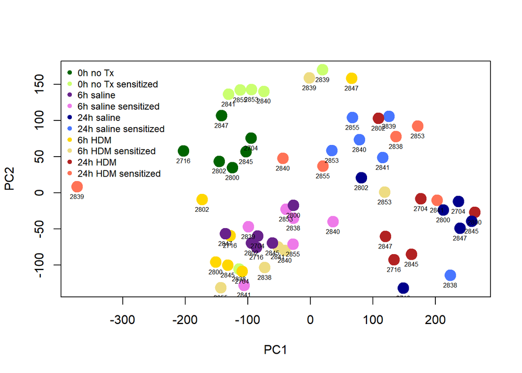

```r
colors <- META$ColorSens
labels <- META$Label
legendlabels <- c("0h no Tx","0h no Tx sensitized","6h saline", "6h saline sensitized","24h saline","24h saline sensitized","6h HDM","6h HDM sensitized","24h HDM","24h HDM sensitized")
legendcolors <- c("darkgreen","darkolivegreen1","darkorchid4","orchid2","darkblue","royalblue1","gold","lightgoldenrod2","firebrick","coral1")

plot(pca$x[,1:2],  col=colors, pch=19, cex=2.0)
text(pca$x[,1:2], labels=labels, col="black", pos=1, cex=0.5)
legend("topleft", legend= legendlabels, col=legendcolors, bty="n", horiz=FALSE, cex=0.75, pch=19)
```

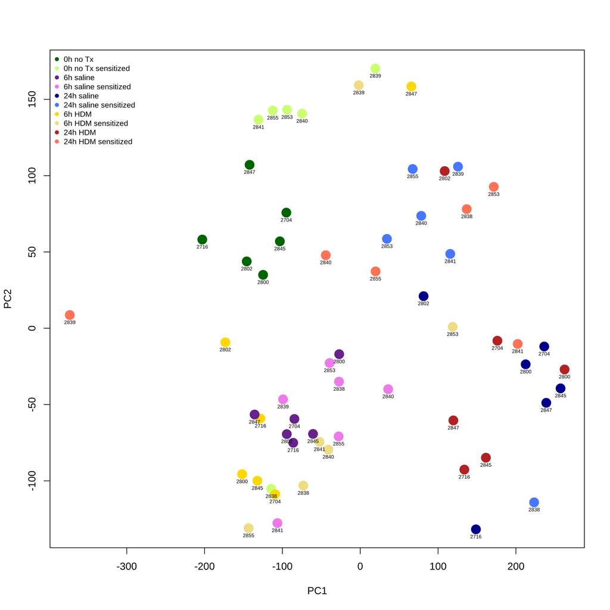

```r
#this pca was finalized with the same code above after the line tiff("Schamber_2dPCA_preliminary.tiff", width=10, height=10, units='in', res=300)
knitr::include_graphics("./results/Schamber_2d_PCA_with_all_variables_lower_res.png")
```

## Back to data for additional cleaning

```r
head(pData(gset))
```

```
##                   title geo_accession                status
## GSM1411137    A_2838_0h    GSM1411137 Public on Sep 23 2014
## GSM1411138  A_2838_6h_A    GSM1411138 Public on Sep 23 2014
## GSM1411139  A_2838_6h_S    GSM1411139 Public on Sep 23 2014
## GSM1411140 A_2838_24h_A    GSM1411140 Public on Sep 23 2014
## GSM1411141 A_2838_24h_S    GSM1411141 Public on Sep 23 2014
## GSM1411142    A_2839_0h    GSM1411142 Public on Sep 23 2014
##            submission_date last_update_date type channel_count
## GSM1411137     Jun 12 2014      Sep 23 2014  RNA             1
## GSM1411138     Jun 12 2014      Sep 23 2014  RNA             1
## GSM1411139     Jun 12 2014      Sep 23 2014  RNA             1
## GSM1411140     Jun 12 2014      Sep 23 2014  RNA             1
## GSM1411141     Jun 12 2014      Sep 23 2014  RNA             1
## GSM1411142     Jun 12 2014      Sep 23 2014  RNA             1
##                      source_name_ch1           organism_ch1
## GSM1411137         skin_untreated_0h Canis lupus familiaris
## GSM1411138  skin_treated_allergen_6h Canis lupus familiaris
## GSM1411139    skin_treated_saline_6h Canis lupus familiaris
## GSM1411140 skin_treated_allergen_24h Canis lupus familiaris
## GSM1411141   skin_treated_saline_24h Canis lupus familiaris
## GSM1411142         skin_untreated_0h Canis lupus familiaris
##               characteristics_ch1 characteristics_ch1.1
## GSM1411137 group: sensitized dogs        animal #: 2838
## GSM1411138 group: sensitized dogs        animal #: 2838
## GSM1411139 group: sensitized dogs        animal #: 2838
## GSM1411140 group: sensitized dogs        animal #: 2838
## GSM1411141 group: sensitized dogs        animal #: 2838
## GSM1411142 group: sensitized dogs        animal #: 2839
##            characteristics_ch1.2 characteristics_ch1.3
## GSM1411137              time: 0h       treatment: none
## GSM1411138              time: 6h   treatment: allergen
## GSM1411139              time: 6h     treatment: saline
## GSM1411140             time: 24h   treatment: allergen
## GSM1411141             time: 24h     treatment: saline
## GSM1411142              time: 0h       treatment: none
##            characteristics_ch1.4
## GSM1411137          tissue: skin
## GSM1411138          tissue: skin
## GSM1411139          tissue: skin
## GSM1411140          tissue: skin
```

[output cut: 106 more lines]

```
## GSM1411142     ftp://ftp.ncbi.nlm.nih.gov/geo/samples/GSM1411nnn/GSM1411142/suppl/GSM1411142_A_2839_0h_Slide7-2_1_3-51.txt.gz
##            data_row_count animal #:ch1       group:ch1 time:ch1 tissue:ch1
## GSM1411137          62976         2838 sensitized dogs       0h       skin
## GSM1411138          62976         2838 sensitized dogs       6h       skin
## GSM1411139          62976         2838 sensitized dogs       6h       skin
## GSM1411140          62976         2838 sensitized dogs      24h       skin
## GSM1411141          62976         2838 sensitized dogs      24h       skin
## GSM1411142          62976         2839 sensitized dogs       0h       skin
##            treatment:ch1
## GSM1411137          none
## GSM1411138      allergen
## GSM1411139        saline
## GSM1411140      allergen
## GSM1411141        saline
## GSM1411142          none
```

```r
#head(exprs(gset))

annotation <- read.csv("./data/raw_data/GPL18789-28160.txt", sep="\t", header=TRUE)

probe_to_gene <- annotation[,c(1,10)]
merged_data <- merge(probe_to_gene, exprs(gset), by="row.names")
#merged_data
```

```r
#Remember, our exprs(gset) already had the variance stabilized accross the mean
merged_data <- as.data.frame(merged_data)
#merged_data

no_gene_known_removed <- merged_data %>%
  filter(merged_data$GENE_SYMBOL != "")

numbers_gone <- no_gene_known_removed %>%
  select(-c(Row.names, ID))

#numbers_gone

#design

#Did the code below to make the final raw data copy for data to be used in this experiment
#write.table(numbers_gone, "./data/raw_data/merged_raw_data.txt", sep="\t")
```

Further, half of the dogs are sensitized and half are not, which is also info in our metadata table.

```r
#Looking back at our initial results from our exploratory analysis

#topTable(fit2)
```

# Resources

## References

[Schamber et al.](https://www.ncbi.nlm.nih.gov/pmc/articles/PMC4199687/) Gene Expression in the Skin of Dogs Sensitized to the House Dust Mite (*Dermatophagoides farinae*). G3: Genes, Genomics, Genetics. 2014 Oct; 4(10): 1787-1795. [Accession #GSE58442](https://www.ncbi.nlm.nih.gov/geo/query/acc.cgi?acc=GSE58442)

Edgar R, Domrachev M, Lash AE. Gene Expression Omnibus: NCBI gene expression and hybridization array data repository Nucleic Acids Res. 2002 Jan 1;30(1):207-10 [GEO (Gene Expression Ombnibus) and GEO2R](https://www.ncbi.nlm.nih.gov/geo/)

[Simon et al.](https://brb.nci.nih.gov/techreport/DesignandAnalysisofDNAMicroarrayInvestigations.pdf) Design and Analysis of DNA Microarray Investigations. Springer-Veriag, New York. ISBN ISBN 0-387-00135-2. pp 66-69: Differential Gene Expression in Microarrays.

## R Packages

```r
citation("Biobase")
```

```
##
##   Orchestrating high-throughput genomic analysis with
##   Bioconductor. W. Huber, V.J. Carey, R. Gentleman, ..., M. Morgan
##   Nature Methods, 2015:12, 115.
##
## A BibTeX entry for LaTeX users is
##
##   @Article{,
##     author = {W. Huber and V. J. Carey and R. Gentleman and S. Anders and M. Carlson and B. S. Carvalho and H. C. Bravo and S. Davis and L. Gatto and T. Girke and R. Gottardo and F. Hahne and K. D. Hansen and R. A. Irizarry and M. Lawrence and M. I. Love and J. MacDonald and V. Obenchain and A. K…
##     title = {{O}rchestrating high-throughput genomic analysis with {B}ioconductor},
##     journal = {Nature Methods},
##     year = {2015},
##     volume = {12},
##     number = {2},
##     pages = {115--121},
##     url = {http://www.nature.com/nmeth/journal/v12/n2/full/nmeth.3252.html},
##   }
```

```r
citation("GEOquery")
```

```
##
## A BibTeX entry for LaTeX users is
##
##   @Article{,
##     author = {Sean Davis and Paul Meltzer},
##     title = {GEOquery: a bridge between the Gene Expression Omnibus (GEO) and BioConductor},
##     journal = {Bioinformatics},
##     year = {2007},
##     volume = {14},
##     pages = {1846--1847},
##   }
```

```r
citation("limma")
```

```
##
## also try to cite the appropriate methodology articles that
## describe the statistical methods implemented in limma, depending
## on which limma functions you are using.  The methodology articles
## are listed in Section 2.1 of the limma User's Guide.
##
##   Ritchie, M.E., Phipson, B., Wu, D., Hu, Y., Law, C.W., Shi, W.,
##   and Smyth, G.K. (2015). limma powers differential expression
##   analyses for RNA-sequencing and microarray studies. Nucleic
##   Acids Research 43(7), e47.
##
## A BibTeX entry for LaTeX users is
##
##   @Article{,
##     author = {Matthew E Ritchie and Belinda Phipson and Di Wu and Yifang Hu and Charity W Law and Wei Shi and Gordon K Smyth},
##     title = {{limma} powers differential expression analyses for {RNA}-sequencing and microarray studies},
##     journal = {Nucleic Acids Research},
##     year = {2015},
##     volume = {43},
##     number = {7},
##     pages = {e47},
##     doi = {10.1093/nar/gkv007},
##   }
```

## Sample Source Information of raw data from [GEO Data Sets](https://www.ncbi.nlm.nih.gov/gds)

1. N_2847_24h_S Organism: Canis lupus familiaris Source name: skin_treated_saline_24h Platform: GPL18789 Series: GSE58442 FTP download: GEO (TXT) ftp://ftp.ncbi.nlm.nih.gov/geo/samples/GSM1411nnn/GSM1411196/ Sample Accession: GSM1411196 ID: 301411196
2. N_2847_24h_A Organism: Canis lupus familiaris Source name: skin_treated_allergen_24h Platform: GPL18789 Series: GSE58442 FTP download: GEO (TXT) ftp://ftp.ncbi.nlm.nih.gov/geo/samples/GSM1411nnn/GSM1411195/ Sample Accession: GSM1411195 ID: 301411195
3. N_2845_24h_S Organism: Canis lupus familiaris Source name: skin_treated_saline_24h Platform: GPL18789 Series: GSE58442 FTP download: GEO (TXT) ftp://ftp.ncbi.nlm.nih.gov/geo/samples/GSM1411nnn/GSM1411191/ Sample Accession: GSM1411191 ID: 301411191
4. N_2845_24h_A Organism: Canis lupus familiaris Source name: skin_treated_allergen_24h Platform: GPL18789 Series: GSE58442 FTP download: GEO (TXT) ftp://ftp.ncbi.nlm.nih.gov/geo/samples/GSM1411nnn/GSM1411190/ Sample Accession: GSM1411190 ID: 301411190
5. N_2845_0h Organism: Canis lupus familiaris Source name: skin_untreated_0h Platform: GPL18789 Series: GSE58442 FTP download: GEO (TXT) ftp://ftp.ncbi.nlm.nih.gov/geo/samples/GSM1411nnn/GSM1411187/ Sample Accession: GSM1411187 ID: 301411187
6. N_2802_24h_S Organism: Canis lupus familiaris Source name: skin_treated_saline_24h Platform: GPL18789 Series: GSE58442 FTP download: GEO (TXT) ftp://ftp.ncbi.nlm.nih.gov/geo/samples/GSM1411nnn/GSM1411186/ Sample Accession: GSM1411186 ID: 301411186
7. N_2802_24h_A Organism: Canis lupus familiaris Source name: skin_treated_allergen_24h Platform: GPL18789 Series: GSE58442 FTP download: GEO (TXT) ftp://ftp.ncbi.nlm.nih.gov/geo/samples/GSM1411nnn/GSM1411185/ Sample Accession: GSM1411185 ID: 301411185
8. N_2802_0h Organism: Canis lupus familiaris Source name: skin_untreated_0h Platform: GPL18789 Series: GSE58442 FTP download: GEO (TXT) ftp://ftp.ncbi.nlm.nih.gov/geo/samples/GSM1411nnn/GSM1411182/ Sample Accession: GSM1411182 ID: 301411182
9. N_2800_24h_S Organism: Canis lupus familiaris Source name: skin_treated_saline_24h Platform: GPL18789 Series: GSE58442 FTP download: GEO (TXT) ftp://ftp.ncbi.nlm.nih.gov/geo/samples/GSM1411nnn/GSM1411181/ Sample Accession: GSM1411181 ID: 301411181
10. N_2800_24h_A Organism: Canis lupus familiaris Source name: skin_treated_allergen_24h Platform: GPL18789 Series: GSE58442 FTP download: GEO (TXT) ftp://ftp.ncbi.nlm.nih.gov/geo/samples/GSM1411nnn/GSM1411180/ Sample Accession: GSM1411180 ID: 301411180
11. N_2847_0h Organism: Canis lupus familiaris Source name: skin_untreated_0h Platform: GPL18789 Series: GSE58442 FTP download: GEO (TXT) ftp://ftp.ncbi.nlm.nih.gov/geo/samples/GSM1411nnn/GSM1411192/ Sample Accession: GSM1411192 ID: 301411192
12. N_2800_0h Organism: Canis lupus familiaris Source name: skin_untreated_0h Platform: GPL18789 Series: GSE58442 FTP download: GEO (TXT) ftp://ftp.ncbi.nlm.nih.gov/geo/samples/GSM1411nnn/GSM1411177/ Sample Accession: GSM1411177 ID: 301411177
13. N_2716_24h_S Organism: Canis lupus familiaris Source name: skin_treated_saline_24h Platform: GPL18789 Series: GSE58442 FTP download: GEO (TXT) ftp://ftp.ncbi.nlm.nih.gov/geo/samples/GSM1411nnn/GSM1411176/ Sample Accession: GSM1411176 ID: 301411176
14. N_2716_24h_A Organism: Canis lupus familiaris Source name: skin_treated_allergen_24h Platform: GPL18789 Series: GSE58442 FTP download: GEO (TXT) ftp://ftp.ncbi.nlm.nih.gov/geo/samples/GSM1411nnn/GSM1411175/ Sample Accession: GSM1411175 ID: 301411175
15. N_2716_0h Organism: Canis lupus familiaris Source name: skin_untreated_0h Platform: GPL18789 Series: GSE58442 FTP download: GEO (TXT) ftp://ftp.ncbi.nlm.nih.gov/geo/samples/GSM1411nnn/GSM1411172/ Sample Accession: GSM1411172 ID: 301411172
16. N_2704_24h_S Organism: Canis lupus familiaris Source name: skin_treated_saline_24h Platform: GPL18789 Series: GSE58442 FTP download: GEO (TXT) ftp://ftp.ncbi.nlm.nih.gov/geo/samples/GSM1411nnn/GSM1411171/ Sample Accession: GSM1411171 ID: 301411171
17. N_2704_24h_A Organism: Canis lupus familiaris Source name: skin_treated_allergen_24h Platform: GPL18789 Series: GSE58442 FTP download: GEO (TXT) ftp://ftp.ncbi.nlm.nih.gov/geo/samples/GSM1411nnn/GSM1411170/ Sample Accession: GSM1411170 ID: 301411170
18. N_2704_0h Organism: Canis lupus familiaris Source name: skin_untreated_0h Platform: GPL18789 Series: GSE58442 FTP download: GEO (TXT) ftp://ftp.ncbi.nlm.nih.gov/geo/samples/GSM1411nnn/GSM1411167/ Sample Accession: GSM1411167 ID: 301411167
19. A_2855_24h_S Organism: Canis lupus familiaris Source name: skin_treated_saline_24h Platform: GPL18789 Series: GSE58442 FTP download: GEO (TXT) ftp://ftp.ncbi.nlm.nih.gov/geo/samples/GSM1411nnn/GSM1411166/ Sample Accession: GSM1411166 ID: 301411166
20. A_2855_24h_A Organism: Canis lupus familiaris Source name: skin_treated_allergen_24h Platform: GPL18789 Series: GSE58442 FTP download: GEO (TXT) ftp://ftp.ncbi.nlm.nih.gov/geo/samples/GSM1411nnn/GSM1411165/ Sample Accession: GSM1411165 ID: 301411165
21. A_2855_0h Organism: Canis lupus familiaris Source name: skin_untreated_0h Platform: GPL18789 Series: GSE58442 FTP download: GEO (TXT) ftp://ftp.ncbi.nlm.nih.gov/geo/samples/GSM1411nnn/GSM1411162/ Sample Accession: GSM1411162 ID: 301411162
22. A_2853_24h_S Organism: Canis lupus familiaris Source name: skin_treated_saline_24h Platform: GPL18789 Series: GSE58442 FTP download: GEO (TXT) ftp://ftp.ncbi.nlm.nih.gov/geo/samples/GSM1411nnn/GSM1411161/ Sample Accession: GSM1411161 ID: 301411161
23. A_2853_24h_A Organism: Canis lupus familiaris Source name: skin_treated_allergen_24h Platform: GPL18789 Series: GSE58442 FTP download: GEO (TXT) ftp://ftp.ncbi.nlm.nih.gov/geo/samples/GSM1411nnn/GSM1411160/ Sample Accession: GSM1411160 ID: 301411160
24. A_2853_0h Organism: Canis lupus familiaris Source name: skin_untreated_0h Platform: GPL18789 Series: GSE58442 FTP download: GEO (TXT) ftp://ftp.ncbi.nlm.nih.gov/geo/samples/GSM1411nnn/GSM1411157/ Sample Accession: GSM1411157 ID: 301411157
25. A_2841_24h_S Organism: Canis lupus familiaris Source name: skin_treated_saline_24h Platform: GPL18789 Series: GSE58442 FTP download: GEO (TXT) ftp://ftp.ncbi.nlm.nih.gov/geo/samples/GSM1411nnn/GSM1411156/ Sample Accession: GSM1411156 ID: 301411156
26. A_2841_24h_A Organism: Canis lupus familiaris Source name: skin_treated_allergen_24h Platform: GPL18789 Series: GSE58442 FTP download: GEO (TXT) ftp://ftp.ncbi.nlm.nih.gov/geo/samples/GSM1411nnn/GSM1411155/ Sample Accession: GSM1411155 ID: 301411155
27. A_2841_0h Organism: Canis lupus familiaris Source name: skin_untreated_0h Platform: GPL18789 Series: GSE58442 FTP download: GEO (TXT) ftp://ftp.ncbi.nlm.nih.gov/geo/samples/GSM1411nnn/GSM1411152/ Sample Accession: GSM1411152 ID: 301411152
28. A_2840_24h_S Organism: Canis lupus familiaris Source name: skin_treated_saline_24h Platform: GPL18789 Series: GSE58442 FTP download: GEO (TXT) ftp://ftp.ncbi.nlm.nih.gov/geo/samples/GSM1411nnn/GSM1411151/ Sample Accession: GSM1411151 ID: 301411151
29. A_2840_24h_A Organism: Canis lupus familiaris Source name: skin_treated_allergen_24h Platform: GPL18789 Series: GSE58442 FTP download: GEO (TXT) ftp://ftp.ncbi.nlm.nih.gov/geo/samples/GSM1411nnn/GSM1411150/ Sample Accession: GSM1411150 ID: 301411150
30. A_2840_0h Organism: Canis lupus familiaris Source name: skin_untreated_0h Platform: GPL18789 Series: GSE58442 FTP download: GEO (TXT) ftp://ftp.ncbi.nlm.nih.gov/geo/samples/GSM1411nnn/GSM1411147/ Sample Accession: GSM1411147 ID: 301411147
31. A_2839_24h_S Organism: Canis lupus familiaris Source name: skin_treated_saline_24h Platform: GPL18789 Series: GSE58442 FTP download: GEO (TXT) ftp://ftp.ncbi.nlm.nih.gov/geo/samples/GSM1411nnn/GSM1411146/ Sample Accession: GSM1411146 ID: 301411146
32. A_2839_24h_A Organism: Canis lupus familiaris Source name: skin_treated_allergen_24h Platform: GPL18789 Series: GSE58442 FTP download: GEO (TXT) ftp://ftp.ncbi.nlm.nih.gov/geo/samples/GSM1411nnn/GSM1411145/ Sample Accession: GSM1411145 ID: 301411145
33. A_2839_0h Organism: Canis lupus familiaris Source name: skin_untreated_0h Platform: GPL18789 Series: GSE58442 FTP download: GEO (TXT) ftp://ftp.ncbi.nlm.nih.gov/geo/samples/GSM1411nnn/GSM1411142/ Sample Accession: GSM1411142 ID: 301411142
34. A_2838_24h_S Organism: Canis lupus familiaris Source name: skin_treated_saline_24h Platform: GPL18789 Series: GSE58442 FTP download: GEO (TXT) ftp://ftp.ncbi.nlm.nih.gov/geo/samples/GSM1411nnn/GSM1411141/ Sample Accession: GSM1411141 ID: 301411141
35. A_2838_24h_A Organism: Canis lupus familiaris Source name: skin_treated_allergen_24h Platform: GPL18789 Series: GSE58442 FTP download: GEO (TXT) ftp://ftp.ncbi.nlm.nih.gov/geo/samples/GSM1411nnn/GSM1411140/ Sample Accession: GSM1411140 ID: 301411140
36. A_2838_0h Organism: Canis lupus familiaris Source name: skin_untreated_0h Platform: GPL18789 Series: GSE58442 FTP download: GEO (TXT) ftp://ftp.ncbi.nlm.nih.gov/geo/samples/GSM1411nnn/GSM1411137/ Sample Accession: GSM1411137 ID: 301411137